# Lab 9

Key

11/13/2018

# Data prep

In the code chunk below, load the appropriate libraries and import the longitudinal.csv dataset.

```r
library(tidyverse)
library(rio)
library(here)
d <- import(here("data", "longitudinal.csv"),
            setclass = "tbl_df")
```

## Scenario

You’d like to evaluate how much students change from one timepoint to the next. You’ve been advised that the best way to do this is with multi-level modeling, but you haven’t taken that class yet, so you want to play around with some preliminary modeling.

1. Use ggplot to display the relation between wave and math scores.

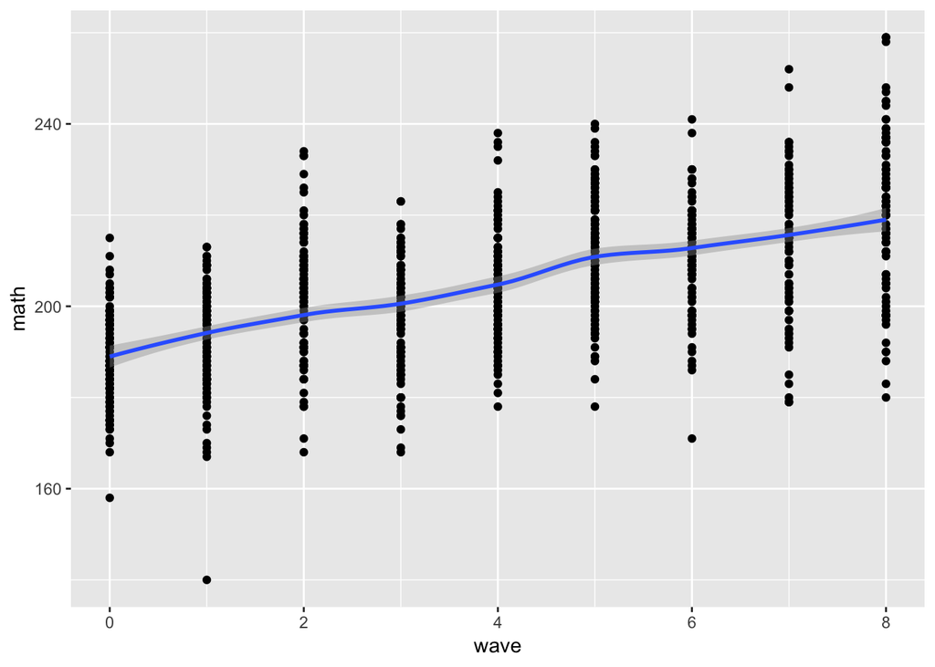

```r
ggplot(d, aes(wave, math)) +
  geom_point() +
  geom_smooth()
```

Discuss what you see in the plot below

2. Fit a linear model with wave predicting their math score. This is model for the average growth across time points. It will assume that all students started at the same point and made the same growth over time (which is why you need multilevel modeling to get away from these assumptions).

```r
m1 <- lm(math ~ wave, d)
summary(m1)
```

```
##
## Call:
## lm(formula = math ~ wave, data = d)
##
## Residuals:
##     Min      1Q  Median      3Q     Max
## -54.100  -8.584   0.488   8.760  39.438
##
## Coefficients:
##             Estimate Std. Error t value Pr(>|t|)
## (Intercept) 190.4621     0.8148  233.75   <2e-16 ***
## wave          3.6375     0.1759   20.68   <2e-16 ***
## ---
## Signif. codes:  0 '***' 0.001 '**' 0.01 '*' 0.05 '.' 0.1 ' ' 1
##
## Residual standard error: 13.32 on 898 degrees of freedom
## Multiple R-squared:  0.3225, Adjusted R-squared:  0.3217
## F-statistic: 427.5 on 1 and 898 DF,  p-value: < 2.2e-16
```

Interpret the model below.

3. Model a quadratic trend below. Display a summary of the models and interpret them below.

```r
m2 <- lm(math ~ poly(wave, 2, raw = TRUE), d)
summary(m2)
```

```
##
## Call:
## lm(formula = math ~ poly(wave, 2, raw = TRUE), data = d)
##
## Residuals:
##     Min      1Q  Median      3Q     Max
## -53.878  -8.599   0.233   9.118  40.366
##
## Coefficients:
##                             Estimate Std. Error t value Pr(>|t|)
## (Intercept)                189.59685    1.08561 174.646  < 2e-16 ***
## poly(wave, 2, raw = TRUE)1   4.37470    0.63622   6.876 1.15e-11 ***
## poly(wave, 2, raw = TRUE)2  -0.09313    0.07724  -1.206    0.228
## ---
## Signif. codes:  0 '***' 0.001 '**' 0.01 '*' 0.05 '.' 0.1 ' ' 1
##
## Residual standard error: 13.32 on 897 degrees of freedom
## Multiple R-squared:  0.3236, Adjusted R-squared:  0.3221
## F-statistic: 214.6 on 2 and 897 DF,  p-value: < 2.2e-16
```

4. Display the fitted quadratic model over the observed data points. Overlay a linear trend as well (make the lines different colors to distinguish them)

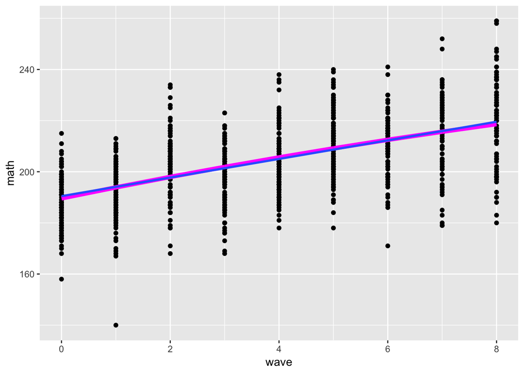

```r
d <- d %>%
  mutate(fitted_m2 = fitted(m2))

ggplot(d, aes(wave, math)) +
  geom_point() +
  geom_line(aes(y = fitted_m2),
            color = "magenta",
            size = 2) +
  geom_smooth(method = "lm",
              se = FALSE)
```

5. Compare the competing models (linear versus quadratic)

```r
anova(m1, m2)
```

```
## Analysis of Variance Table
##
## Model 1: math ~ wave
## Model 2: math ~ poly(wave, 2, raw = TRUE)
##   Res.Df    RSS Df Sum of Sq      F Pr(>F)
## 1    898 159297
## 2    897 159040  1    257.74 1.4537 0.2283
```

```r
sundry::aic_weights(m1, m2)
```

```
##                  predictors     delta weight
## 1                      wave 0.0000000   0.57
## 2 poly(wave, 2, raw = TRUE) 0.5426207   0.43
```

Which model would you preference? State why below.

The linear model should be preferenced given that it is more parsimonious, the plot of the linear versus quadratic trends are nearly indistinguishable, the model including the quadratic trend does not fit the data significantly better, and the linear model has the high AIC weight/lower AIC value.

6. Moving forward with your chosen model, model the different intercepts/slopes for each free/reduced price lunch category. Set Non-FRL as the reference group.

```r
d <- d %>%
  mutate(frl = relevel(factor(frl), ref = "Non-FRL"))

m3 <- lm(math ~ frl*wave, d)
summary(m3)
```

```
##
## Call:
## lm(formula = math ~ frl * wave, data = d)
##
## Residuals:
##     Min      1Q  Median      3Q     Max
## -52.868  -8.721   0.853   8.864  37.705
##
## Coefficients:
##             Estimate Std. Error t value Pr(>|t|)
## (Intercept) 195.1377     1.7257 113.077  < 2e-16 ***
## frlFRL       -5.6957     1.9402  -2.936  0.00341 **
## wave          3.9997     0.3543  11.290  < 2e-16 ***
## frlFRL:wave  -0.5734     0.4042  -1.419  0.15633
## ---
## Signif. codes:  0 '***' 0.001 '**' 0.01 '*' 0.05 '.' 0.1 ' ' 1
##
## Residual standard error: 12.89 on 896 degrees of freedom
## Multiple R-squared:  0.3672, Adjusted R-squared:  0.3651
## F-statistic: 173.3 on 3 and 896 DF,  p-value: < 2.2e-16
```

Provide an interpretation of the coefficients below.

Non-FRL students had an average initial achievement of 195.14 points and progressed, on average, 4.00 points per wave. Students who were eligible for free/reduced price lunch had an initial achievement approximately 5.70 points lower than non-FRL students, or 189.44 points, and progressed approximately 0.57 points less, per wave, or approximately 3.43 points per season.